# Writs of Eviction in VA

Michele Claibourn, Henry DeMarco, and Samantha Toet

2024-05-08

## Background

If a landlord chooses to evict their tenant, they must follow a specific legal process, outlined below. However, not all evictions follow this route. Many tenants are displaced in a form of “informal evictions” that are not documented. Others move upon receiving notice of a lease termination or after receiving a court summons. Still others will move once an eviction judgment has been handed down by the court. For renters that remain, the landlording entity may request the court issue a writ of eviction to be executed by the sheriff. Here we examine the number of formal eviction judgments that reach each of these points, underscoring that the execution of writs of eviction represents a deep undercount of the frequency from which people are displaced from their homes.

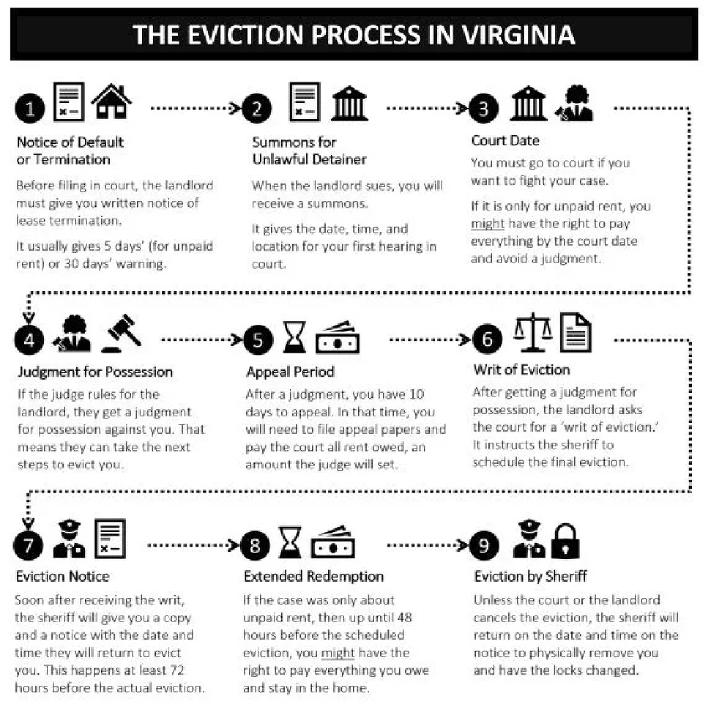

Source: [Virginia Poverty Law Center](https://housing.vplc.org/evictions/)

## Evictions through the Courts

During this period, there were 73027 eviction judgments in Virginia’s general district courts. Of these, 21407 have a record or a writ being issued; 3871 have a record of a writ being executed.

## Timing of Writs

We created a measure to capture the time between when an eviction judgment is made and when a writ of eviction is issued for the 21407 cases with a recorded writ issuance date. Similarly we created a measure for the time between when a writ of eviction is issued and when it is executed for the 3871 caseswith a recorded writ execution date.

### When are writs issued?

#### Timing

Filtering out negative values (cases where the writ issued date occurs before the eviction judgment date), the time between judgments and issued writs ranges between 0 and 164 days. Virginia code stipulates that writs of eviction must be issued within 180 days from the date of judgement for possession.

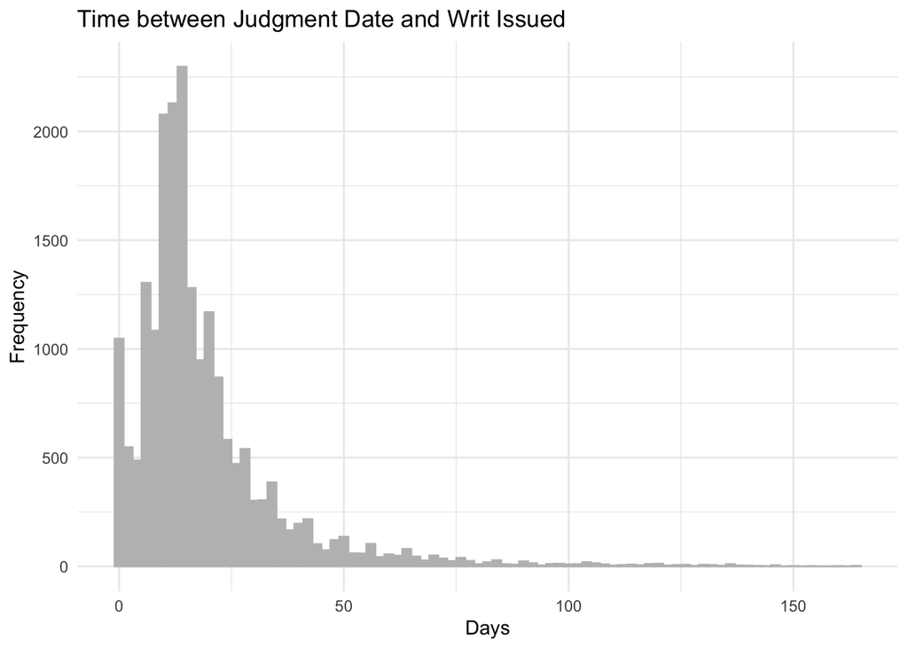

#### Timing by Possession

When a court renders an eviction judgment, the judgment is either for possession or for immediate possession. In a judgment of possession, there is a 10-day appeal period before a writ of eviction can be requested and issued. Under a judgment of immediate possession, the writ of eviction can be requested and issued on the same day as the judgment, but cannot be executed until after the 10-day appeal period.

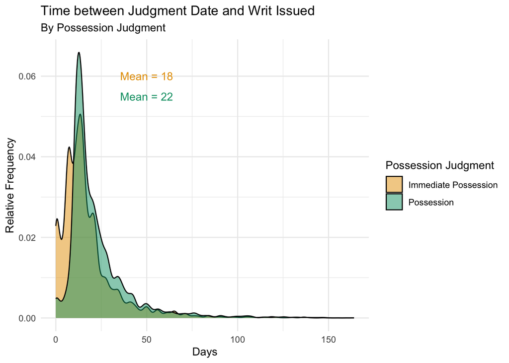

#### Timing among all cases

For the time between judgement and writ issuance, there are notable (and substantial) negative values (2158). A closer look at the negative values suggests that many of these are the result of clerical errors (e.g,. recording the wrong year).

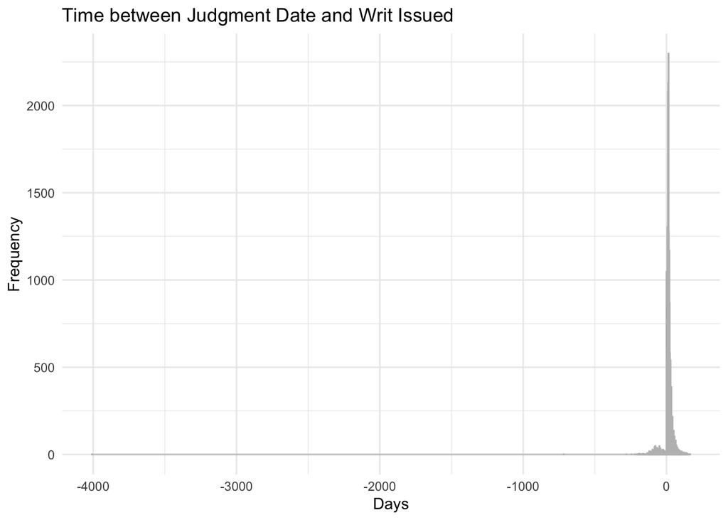

### When are writs executed?

#### Timing

Virginia code stipulates that writs of eviction must be executed within 30 days from issuance (or they will be vacated). Below we filter out improbable values (cases where the writ execution date occurs more than 30 days after the writ issued date).

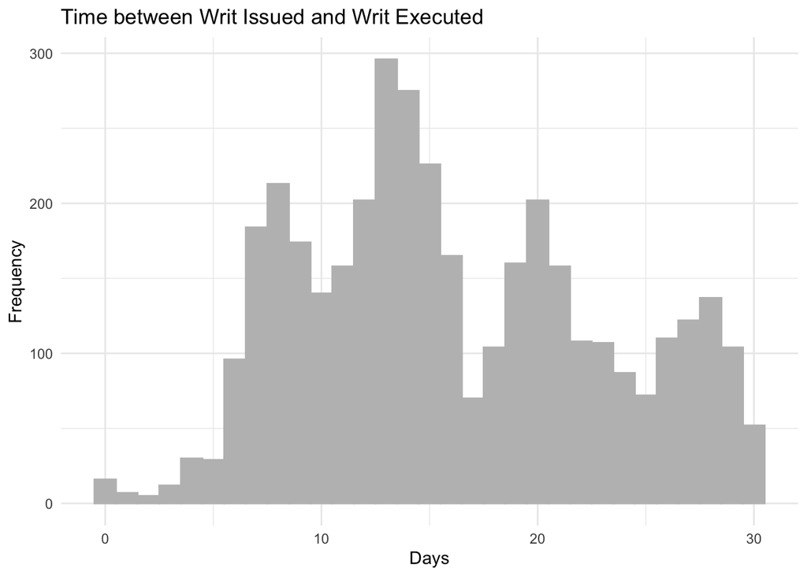

#### Timing by Possession

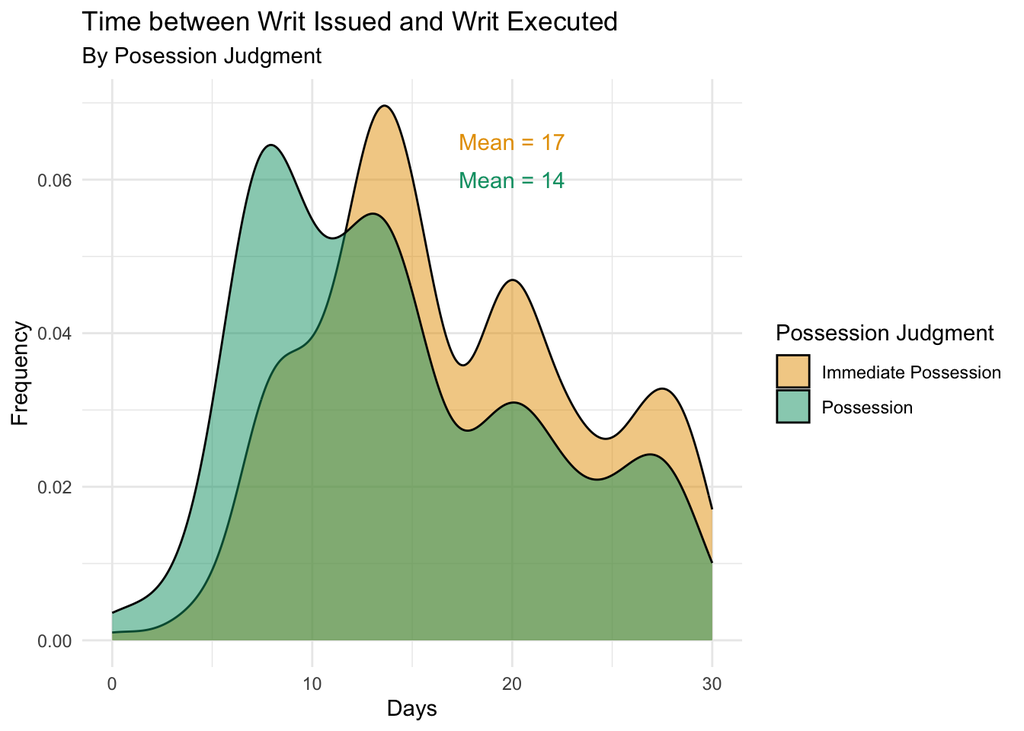

#### Timing among all cases

Among cases with a recorded writ execution date, 50 have execution dates more than 30 days after the date the write of eviction was issued.

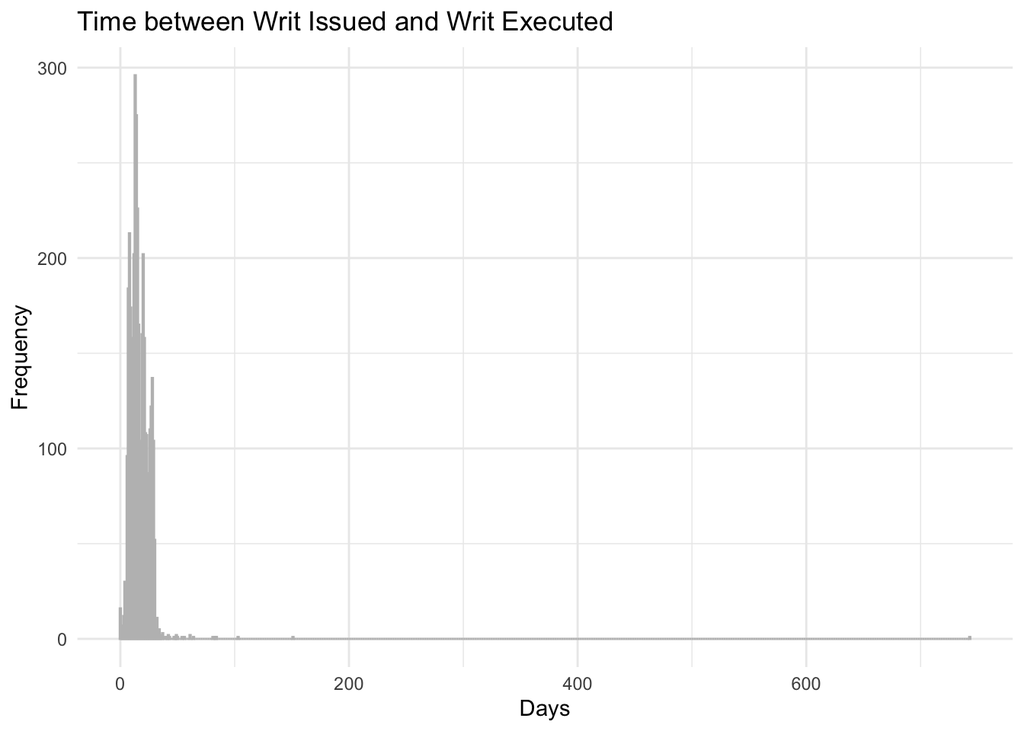

## From Judgment to Executed Writ

Using only the cases resulting in a judgment of eviction, we can show the flow of cases through each subsequent outcome: type of judgment (may not be useful to include), whether a writ is issued, whether a writ is executed. This is intended to visually underscore how few eviction judgments result in executed writs of eviction.

Below are two possible visual types.

### Case Flow (Alluvial)

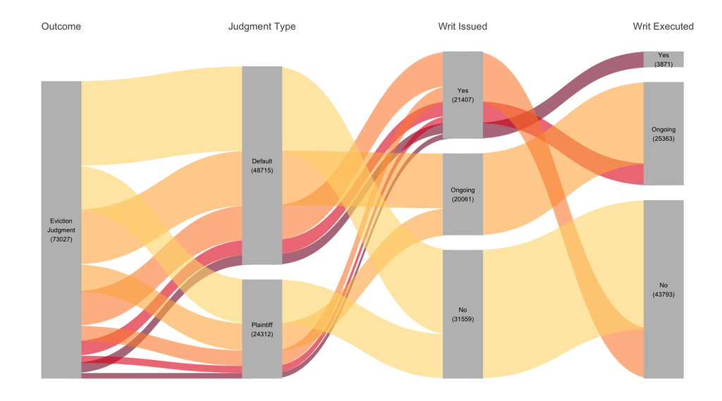

### Case Flow (Sankey)

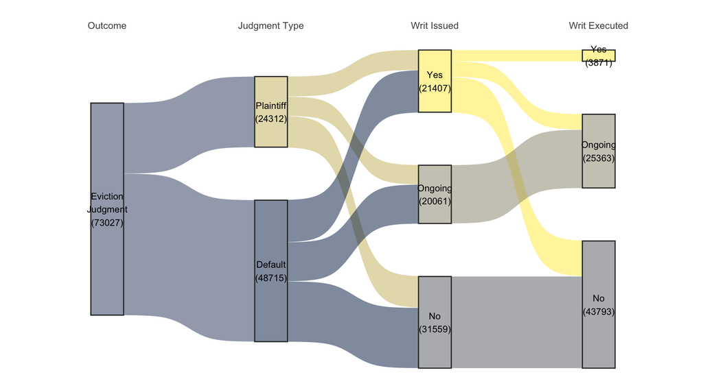

### Additional Thoughts

In a final version, I could imagine adding some background color to represent informal evictions. That is, extending the overall area of the figure by adding background color below the figure. The size of the background color would be approximately proportionate to an estimated number of non-court evictions, but in a way that acknowledges uncertainty (e.g, fuzzy edges or fading out).

Currently just playing with possible color themes, but always looking for suggestions on better uses of color.

Figures could also be oriented vertically to make them bigger.

Finally, we could also begin with a set of cases filed (here all cases filed beginning in January 2023) and include cases that do not result in a formal eviction ruling.

## Judgments and Writs by Area

Below we show the frequency of eviction judgments, writs issued, and writs executed by legal aid service area.

### Eviction Judgment Rates

Among renting households in the area, what percent received an eviction judgement during this period?

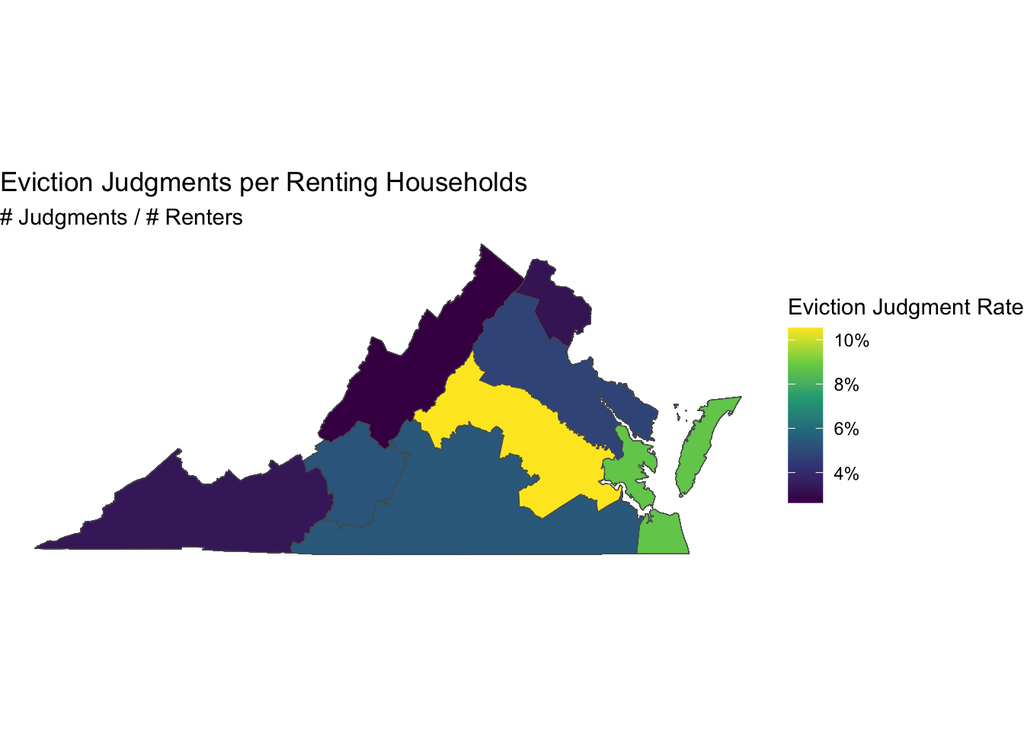

### Writ Issuance Rates

Among all eviction judgments in an area, for how many are writs issued?

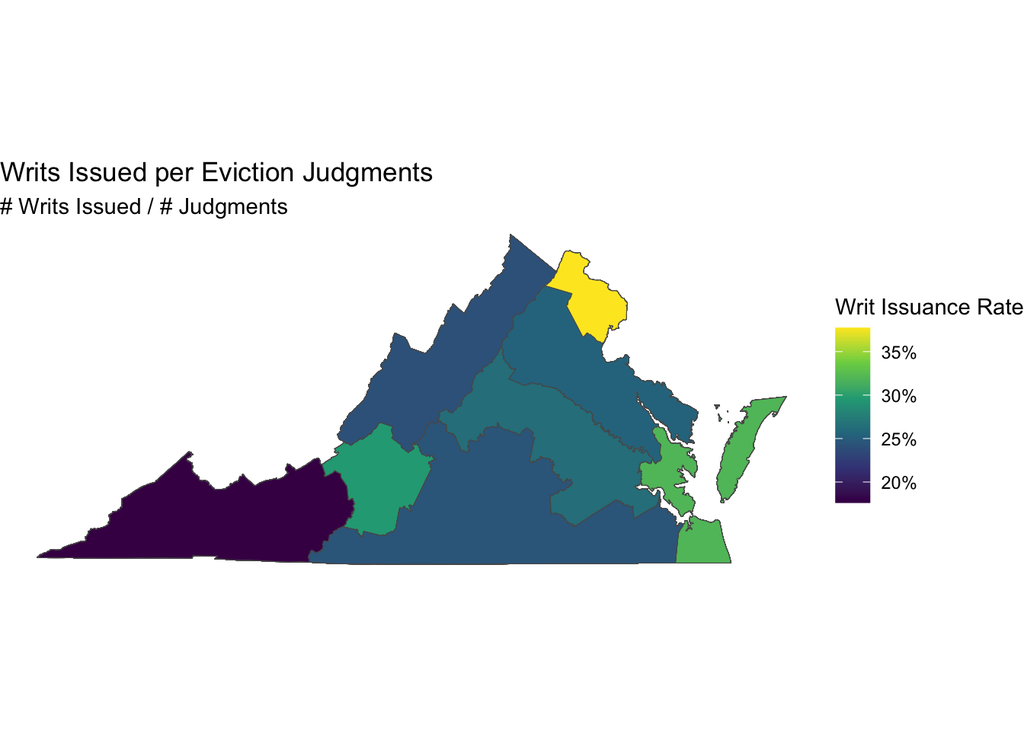

### Writ Execution Rates

Among all eviction judgments for which writs are issued, how many are executed?

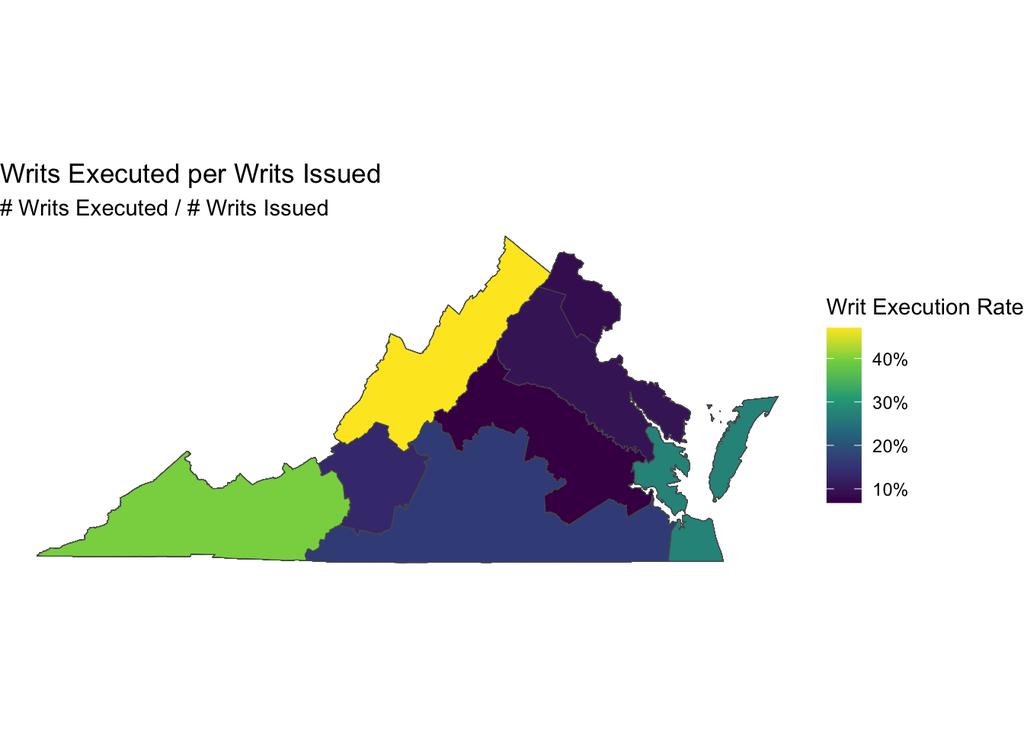

## County Explorer

Patterns in the eviction process by county. The table can be sorted by a column (by clicking on the column name) and filtered by key words (by typing a word in the search box).

Derived measures:

- Rental rate: renting households / total households
- Judgment rate: eviction judgments / renting households
- (Writ) Issuance rate: writs of evictions issued / eviction judgments
- (Writ) Execution rate: writs of evictions executed / writs of evictions issued

Note, several localities report improbably low numbers of executed writs relative to the number of writs issued. For example, Alexandria (0 of 818 issued writs), Arlington (0 of 674), Richmond city (1 of 1903), Prince William (1 of 948), etc.

| county | legal_aid_service_area | estimated_households | renting_households | rental_rate | eviction_judgments | judgment_rate | writs_issued | issuance_rate | writs_executed | execution_rate |
| --- | --- | --- | --- | --- | --- | --- | --- | --- | --- | --- |
| Accomack County | Legal Aid Society of Eastern Virginia | 14252 | 4722 | 0.331321919730564 | 124 | 0.0262600592969081 | 38 | 0.306451612903226 | 0 | 0 |
| Albemarle County | Central Virginia Legal Aid Society | 44031 | 14427 | 0.327655515432309 | 566 | 0.0392319955638733 | 196 | 0.346289752650177 | 2 | 0.0102040816326531 |
| Alleghany County | Blue Ridge Legal Services | 6309 | 1059 | 0.167855444602948 | 116 | 0.109537299338999 | 18 | 0.155172413793103 | 12 | 0.666666666666667 |
| Amelia County | Virginia Legal Aid Society | 5258 | 820 | 0.155952833777102 | 26 | 0.0317073170731707 | 4 | 0.153846153846154 | 2 | 0.5 |
| Amherst County | Virginia Legal Aid Society | 12615 | 3065 | 0.242964724534285 | 168 | 0.0548123980424144 | 60 | 0.357142857142857 | 40 | 0.666666666666667 |
| Appomattox County | Virginia Legal Aid Society | 6535 | 1452 | 0.222188217291507 | 41 | 0.028236914600551 | 10 | 0.24390243902439 | 6 | 0.6 |
| Arlington County | Legal Services of Northern Virginia | 110887 | 64045 | 0.577569958606509 | 1501 | 0.0234366461082052 | 674 | 0.449033977348434 | 0 | 0 |
| Augusta County | Blue Ridge Legal Services | 30056 | 6393 | 0.212702954484961 | 159 | 0.0248709526044111 | 37 | 0.232704402515723 | 2 | 0.0540540540540541 |
| Bath County | Blue Ridge Legal Services | 1905 | 550 | 0.288713910761155 | 1 | 0.00181818181818182 | 0 | 0 | 0 | NaN |
| Bedford County | Legal Aid Society of Roanoke Valley | 32510 | 5120 | 0.157490003075977 | 165 | 0.0322265625 | 26 | 0.157575757575758 | 20 | 0.769230769230769 |

[output cut: 123 more lines]